# Selected Results: 12/18/2024

# 3 Table 2: Predictive model for change in Int. Expenses in the two cycles

```
====================================================
                            Dependent variable:
                        ----------------------------
                         deposit_exp_deposits_chg~
                          2016-2019      2022-2024
                             (1)            (2)
----------------------------------------------------
age                        -0.002**      -0.007***
                           (0.001)        (0.002)
log(family_income)         -0.054**       -0.067*
                           (0.023)        (0.038)
has_dividend_income_pct    -0.0002         0.001
                           (0.001)        (0.001)
college_pct                0.004***      0.006***
                           (0.001)        (0.001)
lag_county_deposit_hhi    -0.085***      -0.134***
                           (0.011)        (0.017)
log(bank_assets)           0.039***      0.091***
                           (0.003)        (0.005)
RUCA1                      0.011***      0.011***
                           (0.002)        (0.003)
Constant                    0.118         -0.044
                           (0.104)        (0.171)
----------------------------------------------------
Observations                4,091          3,615
R2                          0.088          0.161
====================================================
Note:                    *p<0.1; **p<0.05; ***p<0.01
```

```
==============================================================
                                      Dependent variable:
                                  ----------------------------
                                    deposit_exp_deposits_chg
                                     2016-2019     2022-2024
                                        (1)           (2)
--------------------------------------------------------------
I(sophisticated_deposits_pct/100)    0.082***       0.161***
                                      (0.014)       (0.023)
I(age/10)                            -0.030***     -0.079***
                                      (0.009)       (0.016)
lag_county_deposit_hhi               -0.090***     -0.145***
                                      (0.011)       (0.017)
log(bank_assets)                     0.045***       0.099***
                                      (0.003)       (0.005)
RUCA1                                0.009***       0.009***
                                      (0.002)       (0.003)
Constant                              -0.036        -0.221**
                                      (0.056)       (0.094)
--------------------------------------------------------------
Observations                           4,091         3,615
R2                                     0.075         0.149
==============================================================
Note:                              *p<0.1; **p<0.05; ***p<0.01
```

# 4 Table 3: Year by year summary statistics for DF from the models of Table 2

large v. small banks (inputs to the closure models below) Report within bank SD

## 4.1 Density of Deposit Frachise Value per Dollar

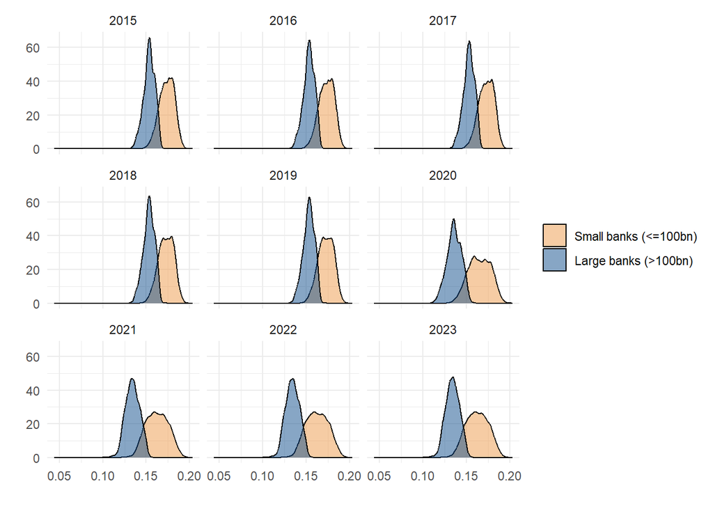

## 4.2 df_per_dollar by year

Sorry, couldn’t get to show the year in each set of rows. Will update it manually when adding this to the paper.

First set of rows is year 2015, next set is 2016, and so on.

### 4.2.1 Large banks

```
|Variable     |Obs  |Mean|SD  |P10 |P25 |P50 |P75 |P90 |
|-------------|-----|----|----|----|----|----|----|----|
|yr           |   NA|  NA|  NA|  NA|  NA|  NA|  NA|  NA|
|df_per_dollar|34025|0.15|0.01|0.14|0.15|0.15|0.16|0.16|
|sophisticated|34025|0.42|0.49|0.00|0.00|0.00|1.00|1.00|
|yr           |   NA|  NA|  NA|  NA|  NA|  NA|  NA|  NA|
|df_per_dollar|33679|0.15|0.01|0.14|0.15|0.15|0.16|0.16|
|sophisticated|33679|0.43|0.49|0.00|0.00|0.00|1.00|1.00|
|yr           |   NA|  NA|  NA|  NA|  NA|  NA|  NA|  NA|
|df_per_dollar|33079|0.15|0.01|0.14|0.15|0.15|0.16|0.16|
|sophisticated|33079|0.43|0.49|0.00|0.00|0.00|1.00|1.00|
|yr           |   NA|  NA|  NA|  NA|  NA|  NA|  NA|  NA|
|df_per_dollar|31802|0.15|0.01|0.14|0.15|0.15|0.16|0.16|
|sophisticated|31802|0.43|0.50|0.00|0.00|0.00|1.00|1.00|
|yr           |   NA|  NA|  NA|  NA|  NA|  NA|  NA|  NA|
|df_per_dollar|30628|0.15|0.01|0.14|0.15|0.15|0.16|0.16|
|sophisticated|30628|0.44|0.50|0.00|0.00|0.00|1.00|1.00|
|yr           |   NA|  NA|  NA|  NA|  NA|  NA|  NA|  NA|
|df_per_dollar|29373|0.14|0.01|0.12|0.13|0.14|0.14|0.15|
|sophisticated|29373|0.45|0.50|0.00|0.00|0.00|1.00|1.00|
|yr           |   NA|  NA|  NA|  NA|  NA|  NA|  NA|  NA|
|df_per_dollar|27258|0.13|0.01|0.12|0.13|0.13|0.14|0.15|
|sophisticated|27258|0.40|0.49|0.00|0.00|0.00|1.00|1.00|
|yr           |   NA|  NA|  NA|  NA|  NA|  NA|  NA|  NA|
|df_per_dollar|26427|0.13|0.01|0.12|0.13|0.13|0.14|0.14|
|sophisticated|26427|0.40|0.49|0.00|0.00|0.00|1.00|1.00|
|yr           |   NA|  NA|  NA|  NA|  NA|  NA|  NA|  NA|
|df_per_dollar|25681|0.13|0.01|0.12|0.13|0.13|0.14|0.14|
|sophisticated|25681|0.40|0.49|0.00|0.00|0.00|1.00|1.00|
```

### 4.2.2 Small banks

```
|Variable     |Obs  |Mean|SD  |P10 |P25 |P50 |P75 |P90 |
|-------------|-----|----|----|----|----|----|----|----|
|yr           |   NA|  NA|  NA|  NA|  NA|  NA|  NA|  NA|
|df_per_dollar|50288|0.17|0.01|0.16|0.17|0.17|0.18|0.18|
|sophisticated|50288|0.30|0.46|0.00|0.00|0.00|1.00|1.00|
|yr           |   NA|  NA|  NA|  NA|  NA|  NA|  NA|  NA|
|df_per_dollar|48556|0.17|0.01|0.16|0.17|0.17|0.18|0.18|
|sophisticated|48556|0.29|0.46|0.00|0.00|0.00|1.00|1.00|
|yr           |   NA|  NA|  NA|  NA|  NA|  NA|  NA|  NA|
|df_per_dollar|46995|0.17|0.01|0.16|0.17|0.17|0.18|0.18|
|sophisticated|46995|0.29|0.45|0.00|0.00|0.00|1.00|1.00|
|yr           |   NA|  NA|  NA|  NA|  NA|  NA|  NA|  NA|
|df_per_dollar|45433|0.17|0.01|0.16|0.17|0.17|0.18|0.18|
|sophisticated|45433|0.29|0.46|0.00|0.00|0.00|1.00|1.00|
|yr           |   NA|  NA|  NA|  NA|  NA|  NA|  NA|  NA|
|df_per_dollar|44150|0.17|0.01|0.16|0.17|0.17|0.18|0.18|
|sophisticated|44150|0.29|0.45|0.00|0.00|0.00|1.00|1.00|
|yr           |   NA|  NA|  NA|  NA|  NA|  NA|  NA|  NA|
|df_per_dollar|43196|0.17|0.01|0.15|0.16|0.17|0.18|0.18|
|sophisticated|43196|0.29|0.45|0.00|0.00|0.00|1.00|1.00|
|yr           |   NA|  NA|  NA|  NA|  NA|  NA|  NA|  NA|
|df_per_dollar|40601|0.16|0.01|0.15|0.15|0.16|0.17|0.18|
|sophisticated|40601|0.27|0.45|0.00|0.00|0.00|1.00|1.00|
|yr           |   NA|  NA|  NA|  NA|  NA|  NA|  NA|  NA|
|df_per_dollar|38421|0.16|0.01|0.15|0.15|0.16|0.17|0.18|
|sophisticated|38421|0.27|0.44|0.00|0.00|0.00|1.00|1.00|
|yr           |   NA|  NA|  NA|  NA|  NA|  NA|  NA|  NA|
|df_per_dollar|37133|0.16|0.01|0.15|0.15|0.16|0.17|0.18|
|sophisticated|37133|0.27|0.44|0.00|0.00|0.00|1.00|1.00|
```

## 4.3 2022 Sample

```
|Variable                        |Obs  |Mean     |SD        |P10     |P25     |P50      |P75      |P90      |
|--------------------------------|-----|---------|----------|--------|--------|---------|---------|---------|
|large_bank                      |   NA|       NA|        NA|      NA|      NA|       NA|       NA|       NA|
|df_per_dollar                   |38421|     0.16|      0.01|    0.15|    0.15|     0.16|     0.17|     0.18|
|sophisticated                   |38421|     0.27|      0.44|    0.00|    0.00|     0.00|     1.00|     1.00|
|age                             |38421|    31.57|     12.91|   11.64|   23.31|    34.59|    41.27|    45.37|
|lag_branch_deposit_amount       |38421|137564.92|1308673.73|16526.00|32854.00| 61377.00|111618.00|200702.00|
|lag_hmda_mtg_amt_gr             |38421|     8.50|     14.12|   -7.22|    0.16|     7.11|    15.94|    26.12|
|lag_cra_loan_amount_amt_lt_1m_gr|38421|   -16.29|     19.26|  -30.52|  -25.56|   -20.49|   -13.50|     0.05|
|lag_county_deposit_hhi          |38421|     0.14|      0.13|    0.03|    0.05|     0.10|     0.18|     0.28|
|establishments_gr               |38421|     0.02|      0.04|   -0.02|    0.00|     0.02|     0.04|     0.06|
|payroll_gr                      |38421|     0.09|      0.10|   -0.02|    0.04|     0.08|     0.13|     0.19|
|no_branches_in_zipcode          |38421|    12.33|      7.90|    6.00|   10.00|    10.00|    10.00|    20.00|
|same_zip_prior_3yr_branches     |38421|     0.01|      0.07|    0.00|    0.00|     0.00|     0.00|     0.00|
|legacy_branch                   |38421|     0.92|      0.28|    1.00|    1.00|     1.00|     1.00|     1.00|
|large_bank                      |   NA|       NA|        NA|      NA|      NA|       NA|       NA|       NA|
|df_per_dollar                   |26427|     0.13|      0.01|    0.12|    0.13|     0.13|     0.14|     0.14|
|sophisticated                   |26427|     0.40|      0.49|    0.00|    0.00|     0.00|     1.00|     1.00|
|age                             |26427|    31.18|     11.69|   14.34|   24.19|    32.96|    39.79|    44.19|
|lag_branch_deposit_amount       |26427|375451.69|6330728.17|41698.60|68883.50|118042.00|202947.00|350028.20|
|lag_hmda_mtg_amt_gr             |26427|     8.87|     11.19|   -3.29|    1.90|     7.54|    14.88|    22.55|
|lag_cra_loan_amount_amt_lt_1m_gr|26427|   -21.15|      8.75|  -28.13|  -25.81|   -22.35|   -18.46|   -12.97|
|lag_county_deposit_hhi          |26427|     0.10|      0.11|    0.02|    0.03|     0.05|     0.12|     0.21|
|establishments_gr               |26427|     0.02|      0.03|   -0.02|    0.00|     0.02|     0.03|     0.06|
|payroll_gr                      |26427|     0.08|      0.09|   -0.01|    0.04|     0.08|     0.13|     0.18|
|no_branches_in_zipcode          |26427|    14.29|      8.28|    9.00|   10.00|    10.00|    20.00|    25.00|
|same_zip_prior_3yr_branches     |26427|     0.02|      0.14|    0.00|    0.00|     0.00|     0.00|     0.00|
|legacy_branch                   |26427|     0.92|      0.27|    1.00|    1.00|     1.00|     1.00|     1.00|
```

# 5 Fg. 3: Scatter plot of predicted DF, early v. late cycle

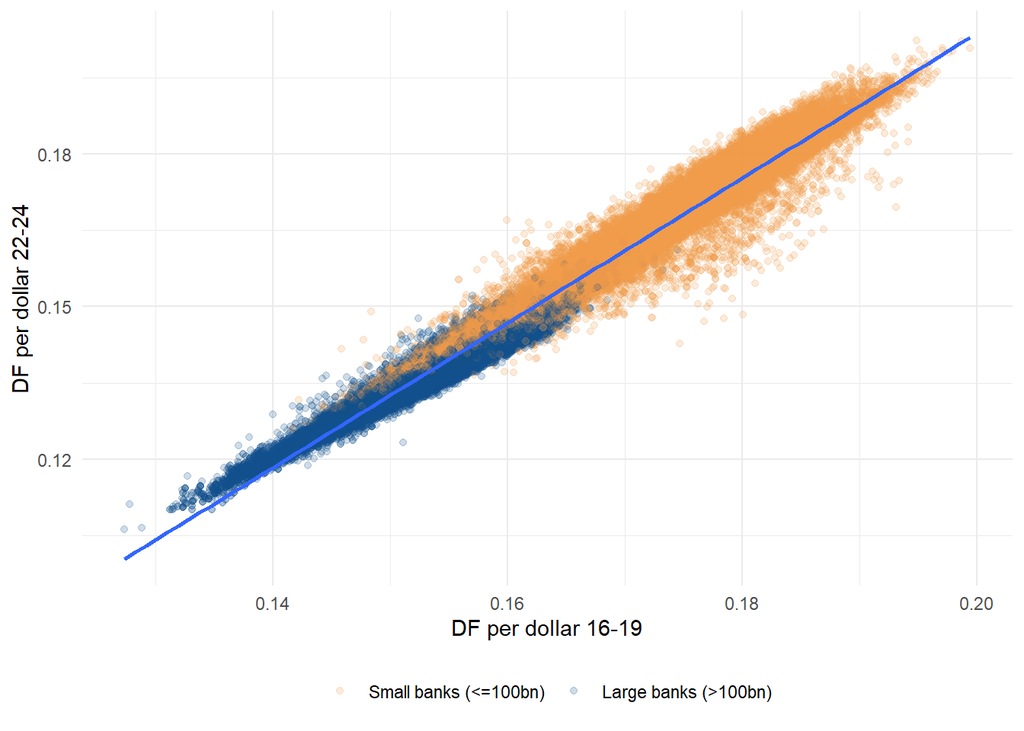

# 6 Table 4: Baseline Closure Model

```
Full Sample
=====================================================================
                                             Dependent variable:
                                        -----------------------------
                                                Linear Prob.
                                           (1)       (2)       (3)
---------------------------------------------------------------------
df_per_dollar                           -0.721*** -1.109*** -0.333***
                                         (0.123)   (0.173)   (0.085)
log(lag_branch_deposit_amount)          -0.025*** -0.031*** -0.020***
                                         (0.001)   (0.002)   (0.001)
I(county_deposit_gr/100)                -0.011*** -0.015***  -0.003
                                         (0.003)   (0.005)   (0.003)
I(lag_hmda_mtg_amt_gr/100)                0.002    -0.011    0.004*
                                         (0.003)   (0.008)   (0.003)
I(lag_cra_loan_amount_amt_lt_1m_gr/100)  -0.0003   -0.001    0.0002
                                         (0.001)   (0.005)   (0.001)
lag_county_deposit_hhi                   0.007**   0.014**    0.002
                                         (0.003)   (0.005)   (0.003)
establishments_gr                       -0.063*** -0.170*** -0.027***
                                         (0.013)   (0.024)   (0.007)
payroll_gr                              -0.005**  -0.007**   -0.002
                                         (0.002)   (0.003)   (0.003)
same_zip_prior_3yr_branches             0.067***  0.084***  0.050***
                                         (0.009)   (0.017)   (0.009)
legacy_branch                           -0.009***  -0.013   -0.008***
                                         (0.002)   (0.008)   (0.002)
---------------------------------------------------------------------
Sample                                    Full      Large     Small
Bank FE                                     Y         Y         Y
State*Year FE                               Y         Y         Y
Urban/Rural Areas                           Y         Y         Y
Observations                             666,597   271,943   394,654
R2                                        0.052     0.042     0.067
=====================================================================
Note:                                     *p<0.1; **p<0.05; ***p<0.01
```

# 7 Table 5 (two panels, large and small banks): Closure Model, year by year

## 7.1 Large Banks

```
=================================================================================================================================
                                                                           Dependent variable:
                                        -----------------------------------------------------------------------------------------
                                           (1)       (2)       (3)       (4)       (5)       (6)       (7)       (8)       (9)
---------------------------------------------------------------------------------------------------------------------------------
df_per_dollar                            -0.528    -0.606*  -0.750**  -1.202**  -1.095*** -2.762***  -0.670*  -1.576*** -1.009***
                                         (0.430)   (0.300)   (0.300)   (0.470)   (0.354)   (0.590)   (0.390)   (0.387)   (0.311)
log(lag_branch_deposit_amount)          -0.018*** -0.027*** -0.027*** -0.034*** -0.034*** -0.054*** -0.034*** -0.034*** -0.024***
                                         (0.004)   (0.003)   (0.004)   (0.004)   (0.005)   (0.011)   (0.005)   (0.006)   (0.005)
I(county_deposit_gr/100)                 -0.005    -0.007   -0.030**    0.002     0.015     0.012    -0.029*  -0.042**   -0.017
                                         (0.005)   (0.011)   (0.011)   (0.013)   (0.010)   (0.012)   (0.016)   (0.017)   (0.016)
I(lag_hmda_mtg_amt_gr/100)               -0.009    -0.022    -0.032*    0.007    -0.012    -0.008    -0.021     0.012     0.047
                                         (0.016)   (0.025)   (0.018)   (0.023)   (0.019)   (0.030)   (0.014)   (0.016)   (0.045)
I(lag_cra_loan_amount_amt_lt_1m_gr/100)  -0.006     0.004   -0.022**   -0.014     0.016     0.016    -0.001     0.030    -0.007
                                         (0.006)   (0.009)   (0.009)   (0.018)   (0.012)   (0.016)   (0.009)   (0.023)   (0.017)
lag_county_deposit_hhi                    0.014    -0.017     0.012    0.027**    0.008     0.021    -0.023    0.041**   0.040**
                                         (0.008)   (0.016)   (0.017)   (0.011)   (0.009)   (0.018)   (0.033)   (0.019)   (0.017)
establishments_gr                        -0.034   -0.162***  -0.084    -0.087*  -0.245*** -0.343*** -0.194*** -0.262*** -0.190***
                                         (0.032)   (0.044)   (0.069)   (0.049)   (0.048)   (0.065)   (0.049)   (0.054)   (0.054)
payroll_gr                              -0.013**   -0.026*   -0.002    -0.0002   -0.035    -0.009     0.002     0.013    -0.008
                                         (0.005)   (0.013)   (0.009)   (0.014)   (0.021)   (0.014)   (0.015)   (0.015)   (0.009)
same_zip_prior_3yr_branches               0.043    -0.036     0.003     0.023    0.059*   0.155***  0.124***    0.019     0.119
                                         (0.046)   (0.031)   (0.024)   (0.030)   (0.031)   (0.012)   (0.016)   (0.018)   (0.115)
legacy_branch                           -0.016**  -0.045*** -0.038***  -0.062*   -0.006     0.015   0.030***    0.012    -0.003
                                         (0.007)   (0.010)   (0.014)   (0.036)   (0.026)   (0.014)   (0.011)   (0.016)   (0.020)
---------------------------------------------------------------------------------------------------------------------------------
Sample                                    2015      2016      2017      2018      2019      2020      2021      2022      2023
Bank FE                                     Y         Y         Y         Y         Y         Y         Y         Y         Y
State*Year FE                               Y         Y         Y         Y         Y         Y         Y         Y         Y
Urban/Rural Areas                           Y         Y         Y         Y         Y         Y         Y         Y         Y
Observations                             34,022    33,676    33,076    31,802    30,628    29,373    27,258    26,427    25,681
R2                                        0.040     0.052     0.042     0.045     0.063     0.071     0.063     0.058     0.027
=================================================================================================================================
Note:                                                                                                 *p<0.1; **p<0.05; ***p<0.01
```

## 7.2 Small banks

```
=================================================================================================================================
                                                                           Dependent variable:
                                        -----------------------------------------------------------------------------------------
                                           (1)       (2)       (3)       (4)       (5)       (6)       (7)       (8)       (9)
---------------------------------------------------------------------------------------------------------------------------------
df_per_dollar                            -0.425    -0.367   -0.682***  -0.171    -0.358   -0.705***  -0.143    -0.130    -0.260*
                                         (0.273)   (0.260)   (0.228)   (0.274)   (0.228)   (0.253)   (0.176)   (0.174)   (0.158)
log(lag_branch_deposit_amount)          -0.022*** -0.019*** -0.019*** -0.017*** -0.016*** -0.031*** -0.023*** -0.016*** -0.014***
                                         (0.002)   (0.002)   (0.002)   (0.001)   (0.001)   (0.002)   (0.002)   (0.002)   (0.002)
I(county_deposit_gr/100)                  0.007     0.010    -0.005    -0.001    -0.001    -0.008   -0.023**   -0.002    -0.001
                                         (0.013)   (0.011)   (0.009)   (0.009)   (0.009)   (0.012)   (0.011)   (0.008)   (0.008)
I(lag_hmda_mtg_amt_gr/100)               -0.001     0.001     0.001     0.003   -0.014**    0.009    0.017*    -0.007    -0.006
                                         (0.009)   (0.008)   (0.006)   (0.007)   (0.007)   (0.009)   (0.009)   (0.008)   (0.009)
I(lag_cra_loan_amount_amt_lt_1m_gr/100)   0.002    -0.005    -0.002     0.002     0.003     0.005    -0.003    -0.001     0.006
                                         (0.004)   (0.004)   (0.004)   (0.004)   (0.003)   (0.005)   (0.005)   (0.005)   (0.004)
lag_county_deposit_hhi                   -0.011    0.021**    0.011     0.003    -0.006    -0.003    -0.001    -0.012    0.021**
                                         (0.009)   (0.010)   (0.008)   (0.008)   (0.006)   (0.009)   (0.009)   (0.008)   (0.010)
establishments_gr                       -0.058**  -0.051**   -0.028    -0.030     0.002    -0.042*   -0.048*   -0.012    -0.007
                                         (0.023)   (0.022)   (0.018)   (0.020)   (0.023)   (0.025)   (0.025)   (0.018)   (0.019)
payroll_gr                                0.002    -0.008    -0.004    -0.004    -0.017     0.002    -0.004    -0.001     0.007
                                         (0.007)   (0.011)   (0.008)   (0.009)   (0.010)   (0.012)   (0.008)   (0.008)   (0.008)
same_zip_prior_3yr_branches             0.051***   0.041**   0.047*     0.063    0.029**  0.071***    0.027    0.055**   0.047*
                                         (0.014)   (0.017)   (0.027)   (0.038)   (0.014)   (0.021)   (0.016)   (0.028)   (0.029)
legacy_branch                            -0.006    -0.006    -0.009*  -0.013**  -0.012*** -0.015***   0.002   -0.011**   -0.009*
                                         (0.005)   (0.005)   (0.005)   (0.005)   (0.004)   (0.006)   (0.005)   (0.005)   (0.004)
---------------------------------------------------------------------------------------------------------------------------------
Sample                                    2015      2016      2017      2018      2019      2020      2021      2022      2023
Bank FE                                     Y         Y         Y         Y         Y         Y         Y         Y         Y
State*Year FE                               Y         Y         Y         Y         Y         Y         Y         Y         Y
Urban/Rural Areas                           Y         Y         Y         Y         Y         Y         Y         Y         Y
Observations                             50,257    48,529    46,960    45,427    44,144    43,192    40,597    38,418    37,130
R2                                        0.154     0.218     0.168     0.164     0.182     0.144     0.167     0.154     0.141
=================================================================================================================================
Note:                                                                                                 *p<0.1; **p<0.05; ***p<0.01
```

# 8 Table 6 (same structure as Table 5): Closure model with sophisticated indicator replacing DF

## 8.1 Large Banks

```
=================================================================================================================================
                                                                           Dependent variable:
                                        -----------------------------------------------------------------------------------------
                                           (1)       (2)       (3)       (4)       (5)       (6)       (7)       (8)       (9)
---------------------------------------------------------------------------------------------------------------------------------
sophisticated                           -0.00003   0.0001    0.006**    0.006     0.004   0.022***    0.008   0.021***   0.008**
                                         (0.003)   (0.001)   (0.003)   (0.004)   (0.003)   (0.006)   (0.005)   (0.004)   (0.004)
age                                      0.0001    0.001**  0.001***   0.001**   0.0003    0.0005    0.0002   -0.0003*   -0.0001
                                        (0.0002)  (0.0002)  (0.0002)  (0.0003)  (0.0002)  (0.0004)  (0.0002)  (0.0002)  (0.0001)
log(lag_branch_deposit_amount)          -0.018*** -0.026*** -0.027*** -0.034*** -0.033*** -0.052*** -0.034*** -0.033*** -0.023***
                                         (0.004)   (0.003)   (0.004)   (0.004)   (0.005)   (0.011)   (0.005)   (0.006)   (0.005)
I(county_deposit_gr/100)                 -0.0001    0.001   -0.026**    0.005     0.015     0.006    -0.028*  -0.039**   -0.016
                                         (0.005)   (0.011)   (0.011)   (0.013)   (0.010)   (0.013)   (0.016)   (0.018)   (0.016)
I(lag_hmda_mtg_amt_gr/100)               -0.016    -0.022   -0.036**   -0.005    -0.023     0.005    -0.022     0.018     0.045
                                         (0.015)   (0.025)   (0.017)   (0.023)   (0.019)   (0.031)   (0.014)   (0.016)   (0.046)
I(lag_cra_loan_amount_amt_lt_1m_gr/100)  -0.005     0.004   -0.019**   -0.012     0.014     0.016    -0.003     0.034    -0.005
                                         (0.006)   (0.009)   (0.008)   (0.018)   (0.011)   (0.016)   (0.009)   (0.023)   (0.017)
lag_county_deposit_hhi                    0.011    -0.018     0.014    0.027**    0.007     0.022    -0.025    0.035*    0.036*
                                         (0.008)   (0.016)   (0.016)   (0.010)   (0.008)   (0.019)   (0.033)   (0.019)   (0.017)
establishments_gr                        -0.028   -0.148***  -0.097    -0.072   -0.237*** -0.319*** -0.183*** -0.271*** -0.192***
                                         (0.033)   (0.046)   (0.068)   (0.050)   (0.048)   (0.066)   (0.049)   (0.055)   (0.054)
payroll_gr                              -0.012**   -0.025*   -0.001     0.006    -0.033    -0.006     0.004     0.015    -0.006
                                         (0.005)   (0.013)   (0.009)   (0.014)   (0.021)   (0.014)   (0.015)   (0.014)   (0.009)
same_zip_prior_3yr_branches               0.043    -0.036     0.003     0.022    0.059*   0.154***  0.124***    0.019     0.119
                                         (0.046)   (0.030)   (0.024)   (0.030)   (0.031)   (0.011)   (0.016)   (0.018)   (0.115)
legacy_branch                           -0.015**  -0.044*** -0.038***  -0.062    -0.007     0.013   0.030***    0.012    -0.003
                                         (0.007)   (0.010)   (0.013)   (0.036)   (0.026)   (0.014)   (0.011)   (0.017)   (0.020)
---------------------------------------------------------------------------------------------------------------------------------
Sample                                    2015      2016      2017      2018      2019      2020      2021      2022      2023
Bank FE                                     Y         Y         Y         Y         Y         Y         Y         Y         Y
State*Year FE                               Y         Y         Y         Y         Y         Y         Y         Y         Y
Urban/Rural Areas                           Y         Y         Y         Y         Y         Y         Y         Y         Y
Observations                             34,022    33,676    33,076    31,802    30,628    29,373    27,258    26,427    25,681
R2                                        0.040     0.052     0.043     0.045     0.063     0.070     0.063     0.057     0.027
=================================================================================================================================
Note:                                                                                                 *p<0.1; **p<0.05; ***p<0.01
```

## 8.2 Small banks

```
=================================================================================================================================
                                                                           Dependent variable:
                                        -----------------------------------------------------------------------------------------
                                           (1)       (2)       (3)       (4)       (5)       (6)       (7)       (8)       (9)
---------------------------------------------------------------------------------------------------------------------------------
sophisticated                             0.001     0.003     0.003    -0.003     0.002    0.006**   0.004*     0.001     0.003
                                         (0.003)   (0.003)   (0.002)   (0.002)   (0.002)   (0.003)   (0.002)   (0.003)   (0.002)
age                                      0.00001   -0.0002   0.0001   -0.00003   -0.0001   -0.0001   -0.0001   0.00002   -0.0001
                                        (0.0002)  (0.0002)  (0.0002)  (0.0002)  (0.0002)  (0.0002)  (0.0001)  (0.0001)  (0.0001)
log(lag_branch_deposit_amount)          -0.022*** -0.019*** -0.019*** -0.016*** -0.016*** -0.030*** -0.023*** -0.016*** -0.014***
                                         (0.002)   (0.002)   (0.002)   (0.001)   (0.001)   (0.002)   (0.002)   (0.002)   (0.002)
I(county_deposit_gr/100)                  0.010     0.011    -0.001     0.002    -0.001    -0.008   -0.023**   -0.001    -0.0004
                                         (0.013)   (0.011)   (0.009)   (0.009)   (0.009)   (0.012)   (0.011)   (0.008)   (0.008)
I(lag_hmda_mtg_amt_gr/100)               -0.003     0.001   -0.00004   -0.0001  -0.015**    0.010    0.016*    -0.008    -0.006
                                         (0.009)   (0.008)   (0.006)   (0.007)   (0.007)   (0.009)   (0.009)   (0.008)   (0.009)
I(lag_cra_loan_amount_amt_lt_1m_gr/100)   0.002    -0.005    -0.002     0.002     0.003     0.005    -0.003    -0.001     0.006
                                         (0.004)   (0.004)   (0.004)   (0.004)   (0.003)   (0.005)   (0.005)   (0.005)   (0.004)
lag_county_deposit_hhi                   -0.014    0.019*     0.007     0.002    -0.008    -0.007    -0.002    -0.012    0.020**
                                         (0.009)   (0.010)   (0.008)   (0.007)   (0.006)   (0.009)   (0.009)   (0.008)   (0.010)
establishments_gr                       -0.057**  -0.051**   -0.030    -0.029     0.001    -0.041*   -0.048*   -0.011    -0.007
                                         (0.023)   (0.022)   (0.019)   (0.020)   (0.023)   (0.025)   (0.025)   (0.018)   (0.019)
payroll_gr                                0.002    -0.008    -0.003    -0.004    -0.017     0.002    -0.004    -0.001     0.008
                                         (0.007)   (0.011)   (0.008)   (0.009)   (0.010)   (0.012)   (0.008)   (0.008)   (0.008)
same_zip_prior_3yr_branches             0.051***   0.041**   0.048*    0.063*    0.029**  0.072***    0.027    0.055**   0.047*
                                         (0.014)   (0.017)   (0.027)   (0.038)   (0.014)   (0.021)   (0.016)   (0.028)   (0.029)
legacy_branch                            -0.006    -0.006    -0.009*  -0.013*** -0.012*** -0.015***   0.002   -0.011**   -0.009*
                                         (0.005)   (0.005)   (0.005)   (0.005)   (0.004)   (0.006)   (0.005)   (0.005)   (0.004)
---------------------------------------------------------------------------------------------------------------------------------
Sample                                    2015      2016      2017      2018      2019      2020      2021      2022      2023
Bank FE                                     Y         Y         Y         Y         Y         Y         Y         Y         Y
State*Year FE                               Y         Y         Y         Y         Y         Y         Y         Y         Y
Urban/Rural Areas                           Y         Y         Y         Y         Y         Y         Y         Y         Y
Observations                             50,257    48,529    46,960    45,427    44,144    43,192    40,597    38,418    37,130
R2                                        0.154     0.218     0.168     0.164     0.182     0.143     0.167     0.154     0.141
=================================================================================================================================
Note:                                                                                                 *p<0.1; **p<0.05; ***p<0.01
```

# 9 Table 7: Closure model, large v. small in 22 and 23 with cell phone branch usage data on RHS

```
Full Sample
=================================================================================================================================
                                                                           Dependent variable:
                                        -----------------------------------------------------------------------------------------
                                                    Full                          Large                         Small
                                           (1)       (2)       (3)       (4)       (5)       (6)       (7)       (8)       (9)
---------------------------------------------------------------------------------------------------------------------------------
df_per_dollar                           -0.529*** -0.392**  -0.326**  -1.063*** -0.775*** -0.651***  -0.089    -0.035    -0.012
                                         (0.155)   (0.152)   (0.137)   (0.221)   (0.222)   (0.202)   (0.098)   (0.097)   (0.102)
log(lag_branch_deposit_amount)          -0.018*** -0.016*** -0.017*** -0.025*** -0.021*** -0.021*** -0.013*** -0.012*** -0.013***
                                         (0.003)   (0.002)   (0.002)   (0.005)   (0.004)   (0.004)   (0.002)   (0.002)   (0.002)
I(county_deposit_gr/100)                 -0.014*   -0.015*  -0.016**  -0.026**  -0.029**  -0.029**   -0.003    -0.003    -0.004
                                         (0.008)   (0.008)   (0.008)   (0.012)   (0.013)   (0.013)   (0.007)   (0.007)   (0.007)
I(lag_hmda_mtg_amt_gr/100)               -0.005    -0.007    -0.005    -0.001    -0.015    -0.012    -0.005    -0.004    -0.003
                                         (0.009)   (0.009)   (0.009)   (0.023)   (0.023)   (0.023)   (0.006)   (0.006)   (0.006)
I(lag_cra_loan_amount_amt_lt_1m_gr/100)  -0.001    -0.001    -0.001    0.00000   -0.004    -0.005   -0.00002   0.00003   0.00001
                                         (0.004)   (0.004)   (0.004)   (0.009)   (0.009)   (0.009)   (0.004)   (0.004)   (0.004)
lag_county_deposit_hhi                  0.020***  0.017***  0.016***  0.029***  0.025***   0.023**    0.007     0.006     0.006
                                         (0.006)   (0.006)   (0.006)   (0.008)   (0.008)   (0.008)   (0.007)   (0.006)   (0.006)
establishments_gr                       -0.087*** -0.070*** -0.062*** -0.166*** -0.125*** -0.113**   -0.028    -0.022    -0.016
                                         (0.025)   (0.023)   (0.022)   (0.041)   (0.041)   (0.040)   (0.017)   (0.017)   (0.016)
payroll_gr                                0.001    -0.001    -0.0003   -0.001    -0.006    -0.006     0.004     0.004     0.004
                                         (0.005)   (0.005)   (0.005)   (0.007)   (0.007)   (0.007)   (0.008)   (0.008)   (0.008)
same_zip_prior_3yr_branches               0.048     0.048     0.048     0.061     0.060     0.061    0.034*    0.033*    0.033*
                                         (0.039)   (0.039)   (0.039)   (0.057)   (0.056)   (0.057)   (0.020)   (0.020)   (0.020)
legacy_branch                             0.001     0.002     0.003     0.006     0.008     0.009    -0.002    -0.002    -0.002
                                         (0.005)   (0.005)   (0.005)   (0.011)   (0.010)   (0.010)   (0.003)   (0.003)   (0.003)
distance_from_home_km_2019              0.00003*   0.00001   0.00000   0.0001    0.00000   0.00000   0.00002   0.00001   0.00001
                                        (0.00002) (0.00001) (0.00001) (0.00005) (0.00002) (0.00002) (0.00001) (0.00001) (0.00001)
log(time_spent_min_2019)                          0.006***  0.006***            0.010***  0.010***            0.003***  0.003***
                                                   (0.001)   (0.001)             (0.001)   (0.001)            (0.0005)   (0.001)
log(no_of_visitors_per_1000_deposits)              0.004**    0.004               0.006     0.005              0.002**   0.002*
                                                   (0.002)   (0.002)             (0.004)   (0.004)             (0.001)   (0.001)
I(chg_no_of_visitors - 1)                                    -0.008                        -0.011                       -0.005**
                                                             (0.006)                       (0.011)                       (0.002)
I(chg_time_spent - 1)                                       0.002***                      0.003***                       0.001*
                                                             (0.001)                       (0.001)                      (0.0005)
---------------------------------------------------------------------------------------------------------------------------------
Bank FE                                     Y         Y         Y         Y         Y         Y         Y         Y         Y
State*Year FE                               Y         Y         Y         Y         Y         Y         Y         Y         Y
Urban/Rural Areas                           Y         Y         Y         Y         Y         Y         Y         Y         Y
Observations                             96,002    96,002    95,734    45,495    45,495    45,424    50,507    50,507    50,310
R2                                        0.057     0.060     0.060     0.032     0.036     0.037     0.109     0.110     0.110
=================================================================================================================================
Note:                                                                                                 *p<0.1; **p<0.05; ***p<0.01
```

# 10 Table 8: Model showing that usage data explained by local demo feature (large v. small banks)

Variable definitions:

- *no_visitors:* Mean number of unique visitors to a bank branch in a given month (advan name: RAW_VISITOR_COUNTS). For our purpose yearly average of this number was used.
- *time_spent_mins:* Advan provides median dwell time in minutes of visits for each location monthly. (Advan name: MEDIAN_DWELL_TIME). Yearly average of this number was used.
- *distance_km:* Advan provides the median distance from home travelled by visitors (of visitors whose home they have identified) in meters. (Advan name: DISTANCE_FROM_HOME). We take yearly average.
- *vistors_per_1k_deposits*: Divided the above no_visitors by the branch-level deposits (in 000s).

## 10.1 Descriptive Statistics: year 2022

```
|Variable               |Obs  |Mean |SD   |P10  |P25  |P50  |P75  |P90   |
|-----------------------|-----|-----|-----|-----|-----|-----|-----|------|
|large_bank             |   NA|   NA|   NA|   NA|   NA|   NA|   NA|    NA|
|vistors_per_1k_deposits|25244| 0.04| 0.90| 0.00| 0.00| 0.00| 0.00|  0.01|
|time_spent_mins        |25244|44.56|92.42| 2.75| 3.27| 4.78|32.08|150.23|
|distance_km            |25244| 8.37| 4.60| 3.34| 5.07| 7.65|10.64| 14.16|
|college_pct            |25244|27.11|17.37| 8.28|15.09|23.06|35.84| 52.03|
|has_dividend_income_pct|25244|22.50|11.69|10.09|14.19|20.21|28.07| 38.51|
|family_income          |25244|55.43|31.21|18.84|35.83|52.30|69.32| 94.29|
|large_bank             |   NA|   NA|   NA|   NA|   NA|   NA|   NA|    NA|
|vistors_per_1k_deposits|22661| 0.02| 1.18| 0.00| 0.00| 0.00| 0.00|  0.00|
|time_spent_mins        |22661|18.46|54.38| 2.50| 3.00| 4.00| 7.08| 35.66|
|distance_km            |22661| 6.67| 4.04| 2.87| 3.89| 5.62| 8.34| 11.65|
|college_pct            |22661|33.07|19.50|10.83|18.05|29.27|45.34| 62.07|
|has_dividend_income_pct|22661|25.37|14.01| 9.28|14.58|22.67|34.04| 45.05|
|family_income          |22661|64.91|36.30|25.33|40.03|58.43|83.47|113.14|
```

## 10.2 large v. small banks

```
Full Sample
=================================================================================================
                                                      Dependent variable:
                               ------------------------------------------------------------------
                               log(vistors-per-1k-deposits)  log(time-spent-mins)    distance-km
                                    (1)            (2)          (3)      (4)       (5)      (6)
-------------------------------------------------------------------------------------------------
sophisticated                    -0.143***       -0.044**      0.035    0.017   1.069***   0.352
                                  (0.046)        (0.017)      (0.028)  (0.025)   (0.162)  (0.769)
age                              -0.008***      -0.006***    -0.005*** -0.002*  -0.045***  0.074
                                  (0.002)        (0.001)      (0.001)  (0.001)   (0.009)  (0.054)
log(lag_branch_deposit_amount)   -0.848***      -0.811***    0.166***  0.224*** 0.917***   0.135
                                  (0.050)        (0.012)      (0.033)  (0.016)   (0.128)  (0.410)
-------------------------------------------------------------------------------------------------
Sample                             large          small        large    small     large    small
Bank FE                              Y              Y            Y        Y         Y        Y
County*Year FE                       Y              Y            Y        Y         Y        Y
Urban/Rural Areas                    Y              Y            Y        Y         Y        Y
Observations                       67,475         79,249      67,454    79,181   67,475   79,249
R2                                 0.570          0.767        0.186    0.347     0.715    0.208
=================================================================================================
Note:                                                                 *p<0.1; **p<0.05; ***p<0.01
```

## 10.3 Is the relationship stronger for large banks?

```
Full Sample
============================================================================================
                                                    Dependent variable:
                               -------------------------------------------------------------
                               log(vistors-per-1k-deposits) log(time-spent-mins) distance-km
                                           (1)                      (2)              (3)
--------------------------------------------------------------------------------------------
sophisticated                           -0.067***                 0.088***          0.726
                                         (0.017)                  (0.025)          (0.663)
large_bank
                                         (0.000)                  (0.000)          (0.000)
age                                     -0.005***                 -0.002**          0.039
                                         (0.001)                  (0.001)          (0.043)
log(lag_branch_deposit_amount)          -0.827***                 0.190***         0.478**
                                         (0.024)                  (0.016)          (0.230)
sophisticated:large_bank                  -0.062                 -0.111***          0.194
                                         (0.043)                  (0.032)          (0.633)
large_bank:age                          -0.004***                 -0.003**         -0.053
                                         (0.002)                  (0.001)          (0.034)
--------------------------------------------------------------------------------------------
Bank FE                                     Y                        Y                Y
County*Year FE                              Y                        Y                Y
Urban/Rural Areas                           Y                        Y                Y
Observations                             146,724                  146,635          146,724
R2                                        0.690                    0.301            0.238
============================================================================================
Note:                                                            *p<0.1; **p<0.05; ***p<0.01
```

# 11 Fg. 4: Dynamic d-in-d version of Table 8

## 11.1 Number of unique visitors, LHS: log(number of unique visitors)

### 11.1.1 Regression

```
====================================================================
                                            Dependent variable:
                                        ----------------------------
                                            Large          Small
                                             (1)            (2)
--------------------------------------------------------------------
sophisticated
                                           (0.000)        (0.000)
post_2020
                                           (0.000)        (0.000)
age                                       -0.003***      -0.001***
                                           (0.0003)      (0.0003)
I(lag_hmda_mtg_amt_gr/100)                -0.046***       -0.005
                                           (0.008)        (0.007)
I(lag_county_gdp_gr/100)                    -0.042        -0.049
                                           (0.054)        (0.038)
I(lag_cra_loan_amount_amt_lt_1m_gr/100)   -0.080***      -0.047***
                                           (0.009)        (0.004)
establishments_gr                          0.678***      0.366***
                                           (0.049)        (0.036)
payroll_gr                                  0.003         -0.004
                                           (0.014)        (0.014)
legacy_branch                               0.005          0.010
                                           (0.014)        (0.007)
I(county_deposit_gr/100)                  -0.073***      -0.089***
                                           (0.019)        (0.019)
same_zip_prior_3yr_branches                 0.030         0.057**
                                           (0.027)        (0.024)
log(lag_branch_deposit_amount)              0.010         0.018**
                                           (0.008)        (0.009)
sophisticated:post_2020                   -0.168***      -0.352***
                                           (0.006)        (0.007)
--------------------------------------------------------------------
Branch FE                                     Y              Y
Month FE                                      Y              Y
Observations                               819,868        969,898
R2                                          0.909          0.922
====================================================================
Note:                                    *p<0.1; **p<0.05; ***p<0.01
```

### 11.1.2 Diff-in-diff plots

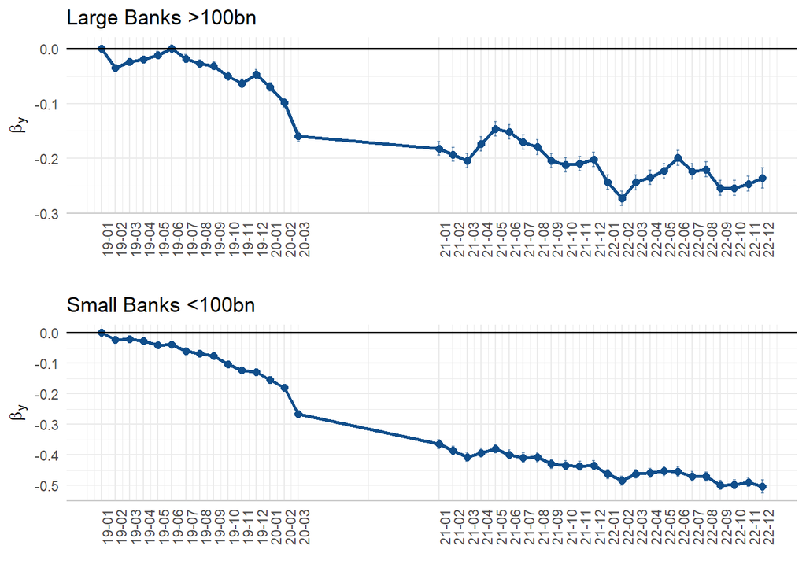

## 11.2 Median time spent at the branch, LHS: log(time_spent_mins)

### 11.2.1 Regressions

```
====================================================================
                                            Dependent variable:
                                        ----------------------------
                                            Large          Small
                                             (1)            (2)
--------------------------------------------------------------------
sophisticated
                                           (0.000)        (0.000)
post_2020
                                           (0.000)        (0.000)
age                                       -0.001***      -0.002***
                                           (0.0004)       (0.001)
I(lag_hmda_mtg_amt_gr/100)                  -0.015        -0.016
                                           (0.016)        (0.017)
I(lag_county_gdp_gr/100)                   0.244***        0.114
                                           (0.084)        (0.083)
I(lag_cra_loan_amount_amt_lt_1m_gr/100)     -0.009       0.044***
                                           (0.015)        (0.012)
establishments_gr                          0.217***       -0.034
                                           (0.076)        (0.087)
payroll_gr                                  -0.006        -0.028
                                           (0.024)        (0.031)
legacy_branch                              -0.050**       -0.015
                                           (0.021)        (0.013)
I(county_deposit_gr/100)                   -0.055*         0.039
                                           (0.029)        (0.037)
same_zip_prior_3yr_branches                 0.036         -0.037
                                           (0.032)        (0.040)
log(lag_branch_deposit_amount)             -0.023*        0.032**
                                           (0.013)        (0.015)
sophisticated:post_2020                     0.011        0.057***
                                           (0.009)        (0.013)
--------------------------------------------------------------------
Branch FE                                     Y              Y
Month FE                                      Y              Y
Observations                               819,457        967,462
R2                                          0.656          0.626
====================================================================
Note:                                    *p<0.1; **p<0.05; ***p<0.01
```

### 11.2.2 Plots

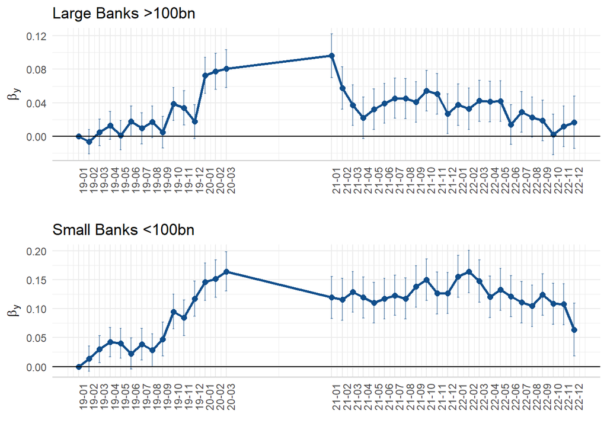

## 11.3 Distance from home, LHS: distance in km

### 11.3.1 Regressions

```
====================================================================
                                            Dependent variable:
                                        ----------------------------
                                            Large          Small
                                             (1)            (2)
--------------------------------------------------------------------
sophisticated
                                           (0.000)        (0.000)
post_2020
                                           (0.000)        (0.000)
age                                       -0.011***      -0.010***
                                           (0.001)        (0.001)
I(lag_hmda_mtg_amt_gr/100)                -0.109***      -0.079**
                                           (0.029)        (0.040)
I(lag_county_gdp_gr/100)                   -0.466**       -0.166
                                           (0.203)        (0.187)
I(lag_cra_loan_amount_amt_lt_1m_gr/100)   -0.190***      -0.112***
                                           (0.036)        (0.026)
establishments_gr                         -0.597***      -0.644***
                                           (0.178)        (0.207)
payroll_gr                                  0.029         -0.025
                                           (0.050)        (0.067)
legacy_branch                              -0.114**      0.104***
                                           (0.044)        (0.026)
I(county_deposit_gr/100)                    0.025          0.001
                                           (0.061)        (0.075)
same_zip_prior_3yr_branches                 -0.008        -0.077
                                           (0.075)        (0.086)
log(lag_branch_deposit_amount)              0.009        0.118***
                                           (0.027)        (0.032)
sophisticated:post_2020                   -0.062***      0.092***
                                           (0.018)        (0.023)
--------------------------------------------------------------------
Branch FE                                     Y              Y
Month FE                                      Y              Y
Observations                               819,868        969,898
R2                                          0.816          0.712
====================================================================
Note:                                    *p<0.1; **p<0.05; ***p<0.01
```

### 11.3.2 Plots

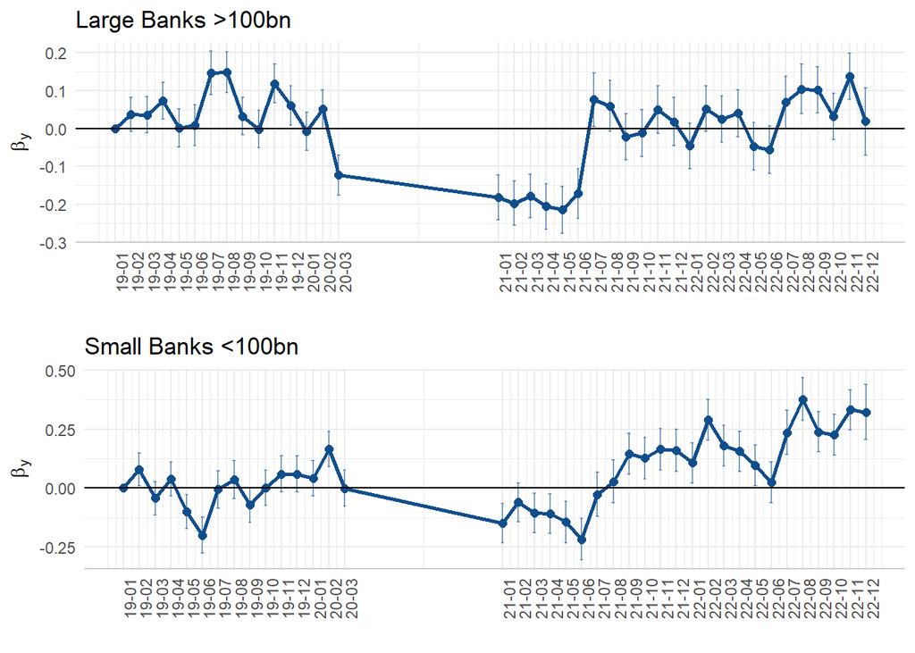